# ps5

2023-02-14

## R Markdown

```
## [1] "/Users/maggieobrien/Desktop/info201"
```

```
## [1] 13055    25
```

13055 rows, 25 columns

```
##    iso3             name iso2   region                      sub.region
## 1   EST          Estonia   EE   Europe                 Northern Europe
## 2   SEN          Senegal   SN   Africa              Sub-Saharan Africa
## 3   GTM        Guatemala   GT Americas Latin America and the Caribbean
## 4   BDI          Burundi   BI   Africa              Sub-Saharan Africa
## 5   SVK         Slovakia   SK   Europe                  Eastern Europe
## 6   ISL          Iceland   IS   Europe                 Northern Europe
## 7   SSD      South Sudan   SS   Africa              Sub-Saharan Africa
## 8   GUY           Guyana   GY Americas Latin America and the Caribbean
## 9   PYF French Polynesia   PF  Oceania                       Polynesia
## 10  SYC       Seychelles   SC   Africa              Sub-Saharan Africa
##    intermediate.region time totalPopulation fertilityRate lifeExpectancy
## 1                      2016         1315790         1.600       77.64146
## 2       Western Africa 1989         7303517         6.555       56.81800
## 3      Central America 1985         7884034         5.865       59.66100
```

[output cut: 51 more lines]

Looks good!

```
##   count
## 1   253
```

253 countries in iso3

```
##   count
## 1   249
```

249 countries in iso2

```
##   count
## 1   250
```

250 countries in name

```r
data %>%
  group_by(iso2) %>%
  summarize(num = n_distinct(name)) %>%
  arrange(desc(num))
```

```
## # A tibble: 249 × 2
##    iso2    num
##    <chr> <int>
##  1 ""        2
##  2 "AD"      1
##  3 "AE"      1
##  4 "AF"      1
##  5 "AG"      1
##  6 "AI"      1
##  7 "AL"      1
##  8 "AM"      1
##  9 "AO"      1
## 10 "AQ"      1
## # … with 239 more rows
```

There do not seem to be any codes that correspond to more than one name, with the exception of the missing value.

```r
data %>%
  filter(nchar(iso3) > 3) %>%
  group_by(iso3) %>%
  summarize(num = n_distinct(name)) %>%
  arrange(desc(num))
```

```
## # A tibble: 2 × 2
##   iso3          num
##   <chr>       <int>
## 1 CHANISL         1
## 2 NLD_CURACAO     1
```

When I tried to find any repeating iso3 values, I found that there were not any (same code as above, without filter line). Because of the hint, I added the filter line to discover the iso3 codes that were confusing me. NLD Curacao, GBM, KOS, Chatisl all have lots of missing data.

```
##    max  min
## 1 2019 1960
```

Max year is 2019, min year is 1960.

```
## # A tibble: 61 × 2
##     time count
##    <int> <int>
##  1  1960    60
##  2  1961    60
##  3  1962    58
##  4  1963    57
##  5  1964    51
##  6  1965    51
##  7  1966    51
##  8  1967    51
##  9  1968    51
## 10  1969    51
## # … with 51 more rows
```

2658 missings for CO2 column total, 1960/1961 have most missings

```
## # A tibble: 61 × 2
##     time count
##    <int> <int>
##  1  1960    60
##  2  1961    60
##  3  1962    58
##  4  1963    57
##  5  1964    51
##  6  1965    51
##  7  1966    51
##  8  1967    51
##  9  1968    51
## 10  1969    51
## # … with 51 more rows
```

2661 missings for CO2_PC column, 1960/1961 have most missings

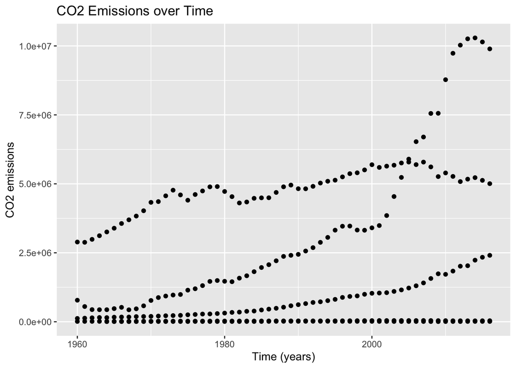

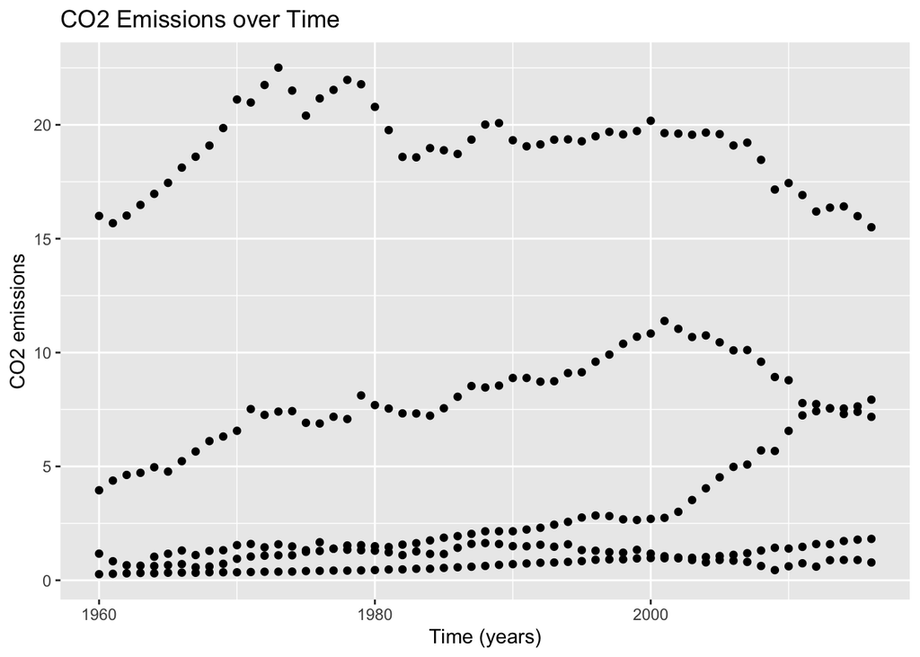

```
## # A tibble: 294 × 3
## # Groups:   time [57]
##     time region    mean
##    <int> <chr>    <dbl>
##  1  1960 Africa   0.291
##  2  1960 Americas 7.15
##  3  1960 Asia     1.74
##  4  1960 Europe   5.77
##  5  1960 Oceania  2.73
##  6  1961 Africa   0.300
##  7  1961 Americas 7.38
##  8  1961 Asia     2.06
##  9  1961 Europe   5.92
## 10  1961 Oceania  2.85
## # … with 284 more rows
```

```
## # A tibble: 11 × 3
## # Groups:   time [2]
##     time region       mean
##    <int> <chr>       <dbl>
##  1  1960 "Africa"    0.291
##  2  1960 "Americas"  7.15
##  3  1960 "Asia"      1.74
##  4  1960 "Europe"    5.77
##  5  1960 "Oceania"   2.73
##  6  2016 ""         19.4
##  7  2016 "Africa"    1.20
##  8  2016 "Americas"  4.80
##  9  2016 "Asia"      6.47
## 10  2016 "Europe"    6.64
## 11  2016 "Oceania"   4.57
```

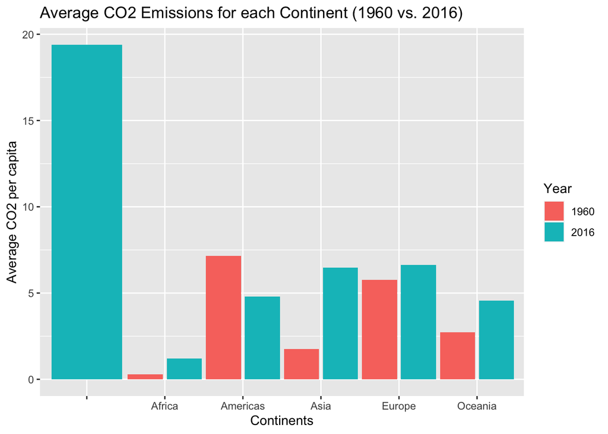

The data for the first NA region is presented here…please disregard. It has a mean of 19.4, and I am unsure of why the code is doing this, even though I skipped NAs.

```
## # A tibble: 204 × 3
## # Groups:   region [6]
##    name                   region     co2_PC
##    <chr>                  <chr>       <dbl>
##  1 "Qatar"                "Asia"       38.9
##  2 ""                     ""           33.8
##  3 "Trinidad and Tobago"  "Americas"   31.8
##  4 "Kuwait"               "Asia"       25.0
##  5 "Bahrain"              "Asia"       22.2
##  6 "United Arab Emirates" "Asia"       22.0
##  7 "New Caledonia"        "Oceania"    19.3
##  8 "Gibraltar"            "Europe"     18.8
##  9 "Brunei Darussalam"    "Asia"       18.3
## 10 "Saudi Arabia"         "Asia"       17.4
## # … with 194 more rows
```

```
## # A tibble: 204 × 3
## # Groups:   region [6]
##    name                              region co2_PC
##    <chr>                             <chr>   <dbl>
##  1 Congo, Democratic Republic of the Africa 0.0256
##  2 Somalia                           Africa 0.0455
##  3 Burundi                           Africa 0.0472
##  4 Central African Republic          Africa 0.0655
##  5 Chad                              Africa 0.0698
##  6 Malawi                            Africa 0.0754
##  7 Rwanda                            Africa 0.0955
##  8 Niger                             Africa 0.0970
##  9 Uganda                            Africa 0.143
## 10 Ethiopia                          Africa 0.144
## # … with 194 more rows
```

Bottom emitters for 2016 - Congo, Somalia, and Burundi. Top emitters for 2016 - Qatar, Trinidad and Tobago, Kuwait

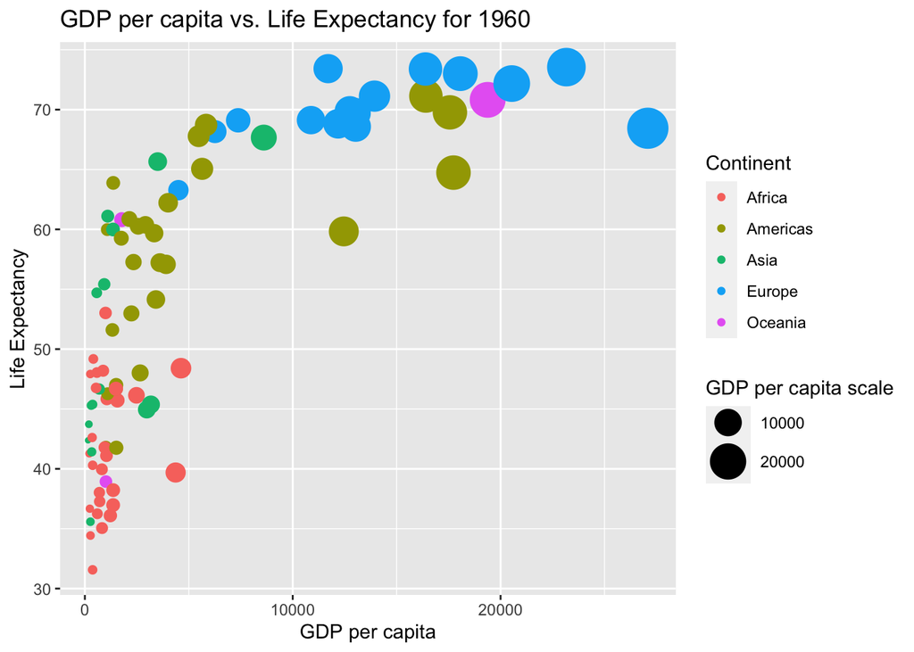

```r
data %>%
  filter(is.na(GDP_PC) == FALSE,
         time == "1960",
         is.na(lifeExpectancy) == FALSE) %>%
  group_by(name) %>%
  ggplot() +
  geom_point(aes(GDP_PC, lifeExpectancy, size=GDP_PC, col=region)) +
  scale_size(range = c(1,10)) +
  labs(title = "GDP per capita vs. Life Expectancy for 1960",
         x = "GDP per capita", y = "Life Expectancy",
       size = "GDP per capita scale",
       color = "Continent")
```

In 1960, European countries had the highest life expectancy, but also the largest GDP per capita. African and some Asian countries had the lowest life expectancy and the smallest GDP.

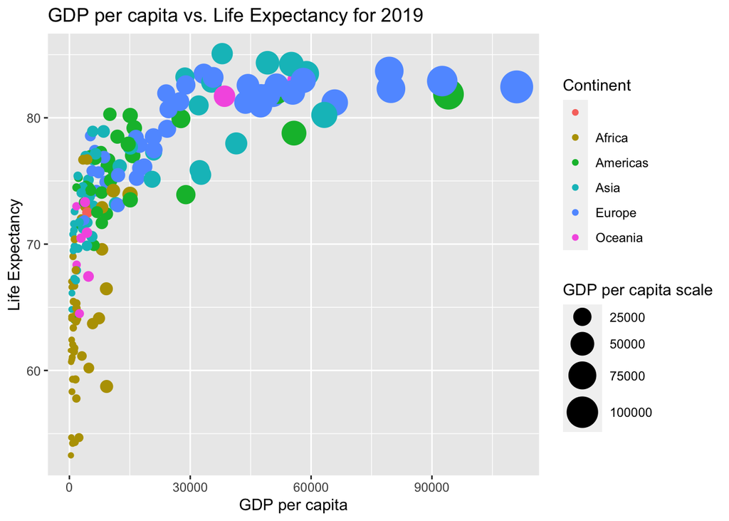

```r
data %>%
  filter(is.na(GDP_PC) == FALSE, !is.na(lifeExpectancy), !is.na(region),
         time == "2019") %>%
  group_by(name) %>%
  ggplot() +
  geom_point(aes(GDP_PC, lifeExpectancy, size=GDP_PC, col=region,
                 na.rm = TRUE)) +
  scale_size(range = c(1,10)) +
  labs(title = "GDP per capita vs. Life Expectancy for 2019",
       x = "GDP per capita", y = "Life Expectancy",
       size = "GDP per capita scale",
       color = "Continent")
```

The biggest difference between the plots is the GDP scale size. The GDP per capita for European and American countries has increased drastically relative to 1960, whereas the GDP per capita for Africa has remained stagnant. The world has developed in the past 60 years and has become more divided amongst continents.

```
## # A tibble: 12 × 3
## # Groups:   region [6]
##    region      time  mean
##    <chr>      <int> <dbl>
##  1 ""          1960  70.7
##  2 ""          2019  77.8
##  3 "Africa"    1960  41.5
##  4 "Africa"    2019  64.1
##  5 "Americas"  1960  58.6
##  6 "Americas"  2019  75.8
##  7 "Asia"      1960  51.6
##  8 "Asia"      2019  74.6
##  9 "Europe"    1960  68.3
## 10 "Europe"    2019  79.4
## 11 "Oceania"   1960  56.4
## 12 "Oceania"   2019  73.5
```

Yes, this makes sense with the figure above! African countries have the shortest life expectancy for both 1960 and 2019, whereas European and American countries have increased their life expectancy over the past 60 years.

```
## # A tibble: 6 × 2
##   region     avggrowthrate
##   <chr>              <dbl>
## 1 "Europe"            1.00
## 2 ""                  1.00
## 3 "Americas"          1.00
## 4 "Oceania"           1.00
## 5 "Asia"              1.01
## 6 "Africa"            1.01
```

Average life expectancy has increased the most for the continent of Africa since 1960 (I’m not sure if this was the calculation Ott wanted, but I believe this is the correct equation for the rate of life expectancy per year). This means that over the past 60 years from 1960-2019, these continents have maintained a steady growth rate. Africa and Asia has the highest rate.

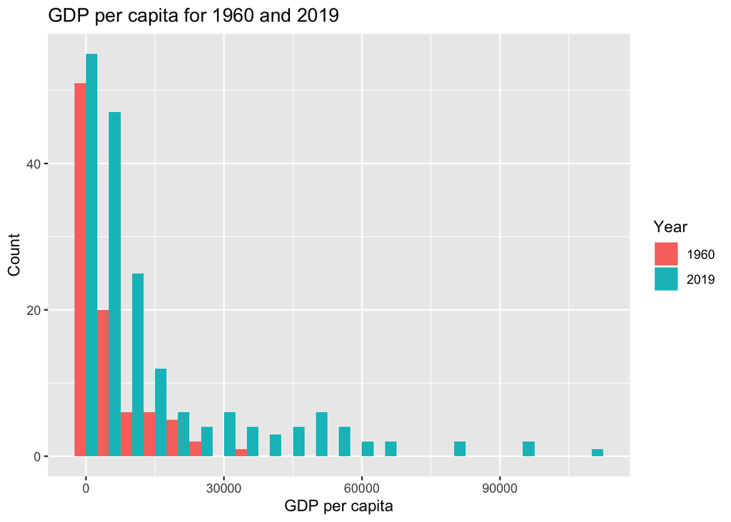

```
## # A tibble: 189 × 3
## # Groups:   lifeExpectancy, time [187]
##    lifeExpectancy name                                                  time
##             <dbl> <chr>                                                <int>
##  1           73.5 Norway                                                1960
##  2           73.4 Iceland                                               1960
##  3           73.4 Netherlands                                           1960
##  4           73.0 Sweden                                                1960
##  5           72.2 Denmark                                               1960
##  6           71.3 Switzerland                                           1960
##  7           71.2 New Zealand                                           1960
##  8           71.1 Canada                                                1960
##  9           71.1 United Kingdom of Great Britain and Northern Ireland  1960
## 10           70.8 Australia                                             1960
## # … with 179 more rows
```

```
## # A tibble: 198 × 3
## # Groups:   lifeExpectancy, time [198]
##    lifeExpectancy name                  time
##             <dbl> <chr>                <int>
##  1           85.1 "Hong Kong"           2019
##  2           84.4 "Japan"               2019
##  3           84.2 "Macao"               2019
##  4           83.7 "Switzerland"         2019
##  5           83.5 "Singapore"           2019
##  6           83.5 "Spain"               2019
##  7           83.2 "Korea, Republic of"  2019
##  8           83.2 "Italy"               2019
##  9           83.1 ""                    2019
## 10           83.0 "Liechtenstein"       2019
## # … with 188 more rows
```

The United States ranking for life expectancy was 17th in 1960.

```
## # A tibble: 198 × 3
## # Groups:   lifeExpectancy [198]
##    lifeExpectancy name                  time
##             <dbl> <chr>                <int>
##  1           85.1 "Hong Kong"           2019
##  2           84.4 "Japan"               2019
##  3           84.2 "Macao"               2019
##  4           83.7 "Switzerland"         2019
##  5           83.5 "Singapore"           2019
##  6           83.5 "Spain"               2019
##  7           83.2 "Korea, Republic of"  2019
##  8           83.2 "Italy"               2019
##  9           83.1 ""                    2019
## 10           83.0 "Liechtenstein"       2019
## # … with 188 more rows
```

In 2019, the United States ranked 47th in terms of life expectancy.

```r
data %>%
  filter(!is.na(time),
         !is.na(lifeExpectancy), !is.na(name)) %>%
  select(time, lifeExpectancy, name) %>%
  group_by(time) %>%
  mutate(rank = rank(lifeExpectancy),
         num = n_distinct(name),
         relativerank = rank / num) %>%
  filter(name == "United States of America", time == "2019")
```

```
## # A tibble: 1 × 6
## # Groups:   time [1]
##    time lifeExpectancy name                      rank   num relativerank
##   <int>          <dbl> <chr>                    <dbl> <int>        <dbl>
## 1  2019           78.8 United States of America   152   197        0.772
```

The United States’ relative rank was 0.77 in 2019, which is down from 0.91 in 1960 (this is different from what it states on the assignment sheet, not sure why).

#### I spent approx. 22 hours on this assignment.